# Homework 8

TJ Schaeffer

4/10/20

```r
# clean up workspace environment
rm(list = ls())

# all packages used for the assignment
library(MASS)
library(car)
library(nortest)
library(dplyr)
library(ggplot2)
library(readr)
library(MuMIn)
library(corrplot)
# reading in data
aphid <- read.csv("aphideData.csv")
```

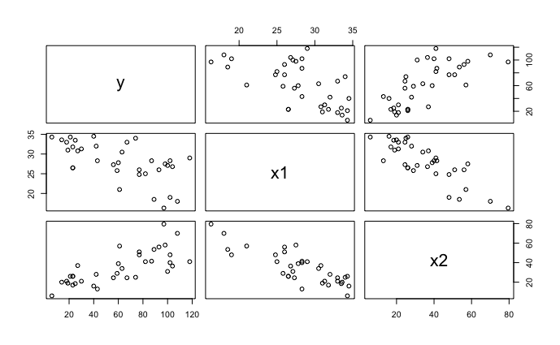

```r
plot(aphid)
```

Based off the scatterplot matrix, it seems that all plots except the two with y and x2 have negative relationships, while the 2 plots with y and x2 seem to have positive relationships. All seem to be strong, linear relationships as well. In simpler terms, with y and x1, it seems that as mean temperature increases, the infestation rate decreases. With x1 and x2, as mean relative humidity increases, it seems that the mean temperature decreases as well. Finally, with y and x2, as mean humidity increases, infestation rates increases.

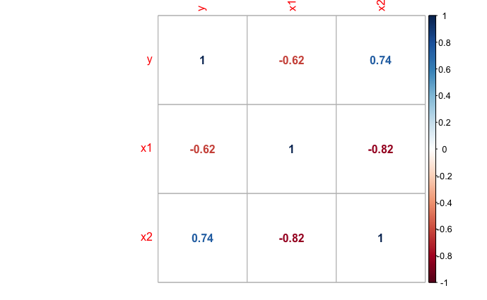

```r
# Creating Correlation Matrix
aphidCorMat <- cor(aphid)

# Obtaining Correlation Plot
corrplot(aphidCorMat, method = "number")
```

Although the correlation between x1 and x2 is a little high at -.82, I do not believe there is any significant correlations to be concerned about multicollinearity.

```r
fit1 <- lm(y~ x1 + x2, data = aphid)
summary(fit1)
```

```
Call:
lm(formula = y ~ x1 + x2, data = aphid)

Residuals:
    Min      1Q  Median      3Q     Max
-35.901 -15.541  -3.053  12.404  48.973

Coefficients:
            Estimate Std. Error t value Pr(>|t|)
(Intercept)  20.0026    52.1131   0.384  0.70364
x1           -0.2902     1.4058  -0.206  0.83779
x2            1.4010     0.4143   3.382  0.00191 **
---
Signif. codes:  0 ‘***’ 0.001 ‘**’ 0.01 ‘*’ 0.05 ‘.’ 0.1 ‘ ’ 1

Residual standard error: 23.11 on 32 degrees of freedom
Multiple R-squared:  0.5483,    Adjusted R-squared:  0.5201
F-statistic: 19.42 on 2 and 32 DF,  p-value: 3.001e-06
```

InfestRate = 20 - .29Temp + 1.4Humid

With all the other variables controlled and equal to 0, the infestation rate is 20 aphids/100 leaves. With the the humidity variable controlled, the infestation rate dropes by .29 aphids/100 leaves for each single unit increase in mean temperature (in Celsius). With the temperature variable controlled, the infestation rate increases by 1.4 aphids/100 leaves for each single percentage increase in mean relative humidity.

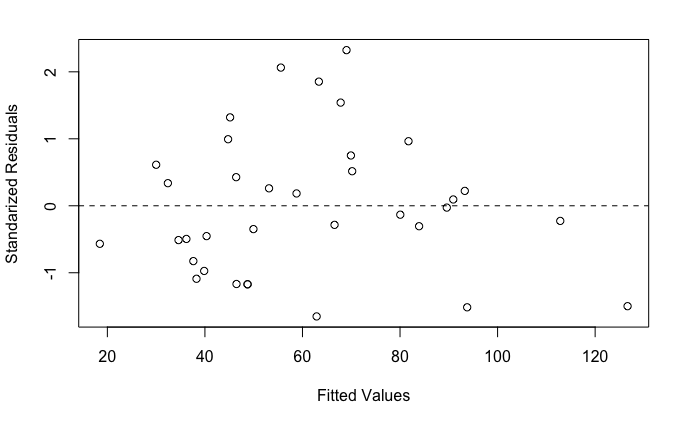

```r
# Std Res
aphid.studentres <- studres(fit1)
aphid.fittedvalues <- fit1$fitted

plot(aphid.studentres~aphid.fittedvalues, ylab = "Standarized Residuals", xlab = "Fitted Values")
abline(h = 0, lty = 2)
```

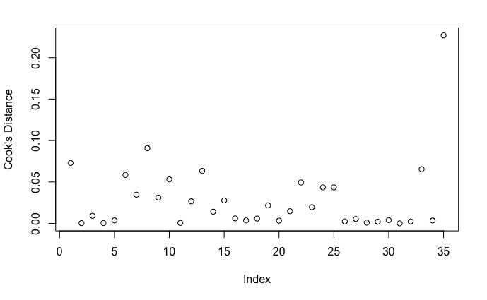

```r
#Cook's Distance
plot(cooks.distance(fit1), ylab = "Cook's Distance")
abline(h = 1, col = "red", lty = 2)
```

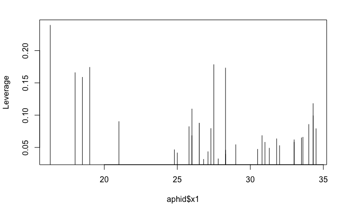

```r
# Leverage Points
plot(hatvalues(fit1)~aphid$x1 + aphid$x2, type = "h", ylab = "Leverage")
```

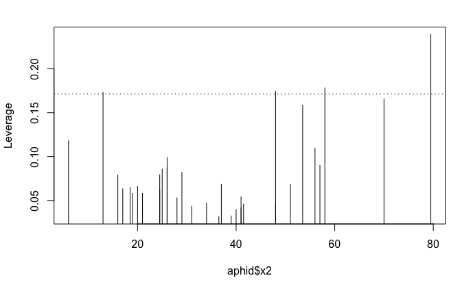

```r
abline(h=((2*3)/nrow(aphid)), lty = "dotted")
```

```r
# Normality
ad.test(aphid.studentres)
```

```
    Anderson-Darling normality test

data:  aphid.studentres
A = 0.29295, p-value = 0.5832
```

```r
# Vif
vif(fit1)
```

```
      x1       x2
3.076691 3.076691
```

|  | StudRes | Hat | CookD |
| --- | --- | --- | --- |
| 5 | 0.2219751 | 0.17832592 | 0.003673676 |
| 6 | 2.0630397 | 0.04341330 | 0.058439659 |
| 8 | 2.3237240 | 0.05426327 | 0.090789535 |
| 35 | -1.4991920 | 0.23933111 | 0.226875065 |

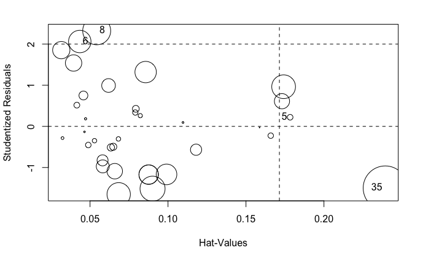

```r
# Influence Plot
influencePlot(fit1)
```

5. H0: B1 = B2 = 0 HA: At least one Bi is not equal to 0.

Conclusion: Since the p-value of the model is less than the alpha of 0.05, we reject the null hypothesis and suggest that there is eveidence that at least one slope is not equal to 0 and that the overall fit of the model is strong.

6. The overall proportion of variability explained by the model fit is 52%, which is the adjusted R^2 value. This value was picked because it’s a stronger statistic of the normal R-squared, as it allows independent variables that have a correlation with the response variable to increase the adj. R- squared value and decrease it with a dependent variable.
7. H0: B2 = 0 HA: B2 != 0

Conclusion: Since the p-value of the model is less than the alpha of 0.05, we reject the null hypothesis and suggest that the humidity variable is a necessary part of the model.

8. H0: B1 = 0 HA: B1 != 0

Conclusion: Since the p-value of the model is greater than the alpha of 0.05, we fail to reject the null hypothesis and suggest that the temperature variable is not a necessary part of the model.

9. Based off the two previous experiments, I have concluded to move forward with only the humidity variable and take out the temperature variable out of the experiment.

```r
fit2 <- lm(y~x2,data = aphid)
summary(fit2)
```

```
Call:
lm(formula = y ~ x2, data = aphid)

Residuals:
    Min      1Q  Median      3Q     Max
-36.847 -15.303  -3.031  13.364  48.268

Coefficients:
            Estimate Std. Error t value Pr(>|t|)
(Intercept)   9.4132     8.9942   1.047    0.303
x2            1.4712     0.2327   6.322 3.75e-07 ***
---
Signif. codes:  0 ‘***’ 0.001 ‘**’ 0.01 ‘*’ 0.05 ‘.’ 0.1 ‘ ’ 1

Residual standard error: 22.78 on 33 degrees of freedom
Multiple R-squared:  0.5477,    Adjusted R-squared:  0.534
F-statistic: 39.96 on 1 and 33 DF,  p-value: 3.755e-07
```

InfestRate = 9.41 + 1.47Humid

When the mean relative humidity is equal to 0, the infestation rate is 9.41 aphids/100 leaves. With each percentage increase in mean relative humidity, the infestation rate increases by 1.47 aphids/100 leaves.

```r
# AIC fit
AICc(fit1,fit2)
```

|  | df | AICc |
| --- | --- | --- |
| fit1 | 4 | 325.3507 |
| fit2 | 3 | 322.8381 |

```r
# ANOVA test
anova(fit1,fit2)
```

```
Analysis of Variance Table

Model 1: y ~ x1 + x2
Model 2: y ~ x2
  Res.Df   RSS Df Sum of Sq      F Pr(>F)
1     32 17095
2     33 17118 -1   -22.756 0.0426 0.8378
```

H0: B1 = 0Ha: B1 != 0Conclusion: Since the p-value of .8378 is larger than the alpha of 0.01, we fail to reject null hypothesis and state that B1 is insignificant to the model.

```r
fit3 <- lm(y~x1, data = aphid)
# AIC fit
AICc(fit2,fit3)
```

|  | df | AICc |
| --- | --- | --- |
| fit2 | 3 | 322.8381 |
| fit3 | 3 | 333.4865 |

```r
# Fit2 summary
summary(fit2)
```

```
Call:
lm(formula = y ~ x2, data = aphid)

Residuals:
    Min      1Q  Median      3Q     Max
-36.847 -15.303  -3.031  13.364  48.268

Coefficients:
            Estimate Std. Error t value Pr(>|t|)
(Intercept)   9.4132     8.9942   1.047    0.303
x2            1.4712     0.2327   6.322 3.75e-07 ***
---
Signif. codes:  0 ‘***’ 0.001 ‘**’ 0.01 ‘*’ 0.05 ‘.’ 0.1 ‘ ’ 1

Residual standard error: 22.78 on 33 degrees of freedom
Multiple R-squared:  0.5477,    Adjusted R-squared:  0.534
F-statistic: 39.96 on 1 and 33 DF,  p-value: 3.755e-07
```

```r
#Fit3 summary
summary(fit3)
```

```
Call:
lm(formula = y ~ x1, data = aphid)

Residuals:
    Min      1Q  Median      3Q     Max
-44.262 -19.554  -2.183  18.081  61.228

Coefficients:
            Estimate Std. Error t value Pr(>|t|)
(Intercept) 178.4601    26.1704   6.819 8.85e-08 ***
x1           -4.1962     0.9195  -4.563 6.64e-05 ***
---
Signif. codes:  0 ‘***’ 0.001 ‘**’ 0.01 ‘*’ 0.05 ‘.’ 0.1 ‘ ’ 1

Residual standard error: 26.52 on 33 degrees of freedom
Multiple R-squared:  0.3869,    Adjusted R-squared:  0.3683
F-statistic: 20.82 on 1 and 33 DF,  p-value: 6.638e-05
```

Since fit2 has a lower AIC value and accounts for a larger adjusted R^2 value, I would choose fit2.

```r
newHumid <- data.frame(x2 = 115)
predict(fit2, newdata = newHumid, interval = 'prediction', level = 0.95)
```

```
       fit      lwr      upr
1 178.6009 118.2207 238.9811
```

No because it seems that the prediction interval is incredibly out of the range of normal values for the response variable.

```r
newHumid <- data.frame(x2 = 65)
predict(fit2, newdata = newHumid, interval = 'confidence', level = 0.95)
```

```
      fit      lwr      upr
1 105.041 88.79078 121.2912
```